# Part II - Ford GoBike System Data Key Insights Presentation

## by Agyo Jephthah Job

## Investigation Overview

> In this investigation, I wanted to look at how long users go on bike rides. If their age or gender affect the duration of these rides. The main focus was on the relationship between variables like the duration, gender, age, start and end time of the users in the data set.

## Dataset Overview

> This data set includes information about individual rides made in a bike-sharing system covering the greater San Francisco Bay area. The dataset was for 2019, Feb.

> The male gender has the higest proportion with about 75%, followed by female with 23%, and Other with 2 %. 90.5% of individuals in the dataset are Subscribers, while 9.5% are Customers. Most of the users fall between the age range of 25 - 45.

## Proportion of user types and genders

> The dataset contains 174952 individual entries. There are 2 user types:
> - 90.5% of individuals in the dataset are Subscribers, while
> - 9.5% are Customers

> There 3 different genders represented:
> - The male gender has the higest proportion with about 75%,
> - Female with 23%,
> - and Other with 2%.

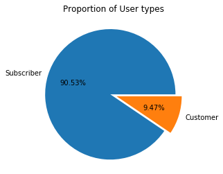

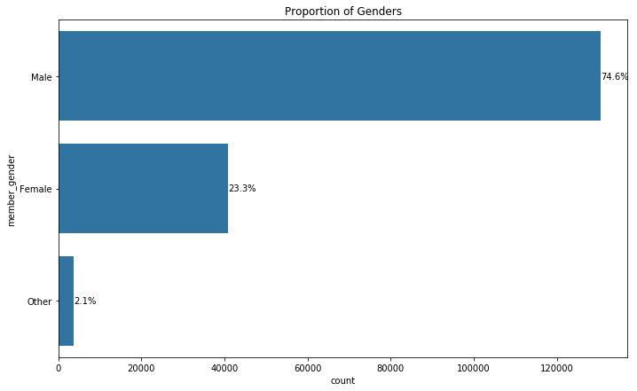

## Age Distribution of all users

> - Users age falls between 17 and 90
> - There are few outliers, ages above 90
> - Most the bikers have age range of 25 - 45 (for all genders)
> - The male gender has more users with ages that are above 45 compared to the rest of the genders.

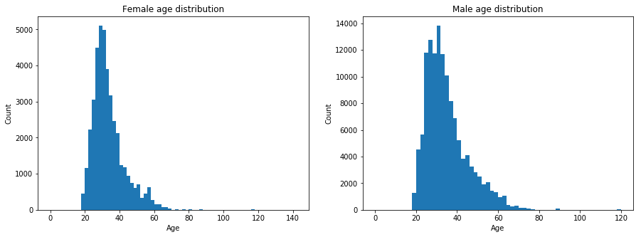

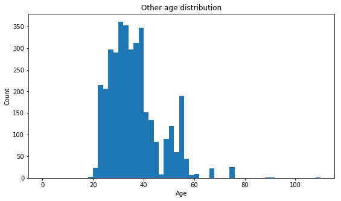

## Relationship between the age of riders and the duration of the rides

> When it comes to the relationship of individual age and how long they went for a bike ride, the older the rider the shorter the ride.
> - Most of the users are clustered around the age of 20 and 60

```
Text(0.5,1,'Relationship between Age and Ride Duration')
```

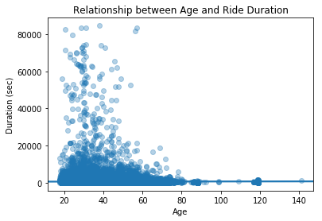

## User types Relationship between start time and end time of rides.

> Looking at the relationship between the start time of users and their end time, for both subscribers and customers.

```
			 Relationship Between Start and End Time (in hours)
```

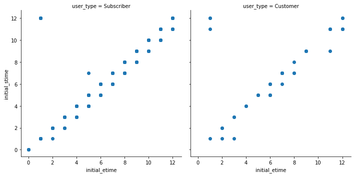

> **Thank you...**

> **The End...**